# Introduction to Statistical Learning - Chapter 10 - Deep Learning - Labs

## Preprocessing

We create a `DataFrame` of one-hot encoded version of the `day_of_week` feature.

```python
nyse_cat_data = pd.get_dummies(nyse_data_raw['day_of_week'])
nyse_cat_data
```

| date | fri | mon | thur | tues | wed |
| --- | --- | --- | --- | --- | --- |
| 1962-12-03 | 0 | 1 | 0 | 0 | 0 |
| 1962-12-04 | 0 | 0 | 0 | 1 | 0 |
| 1962-12-05 | 0 | 0 | 0 | 0 | 1 |
| 1962-12-06 | 0 | 0 | 1 | 0 | 0 |
| 1962-12-07 | 1 | 0 | 0 | 0 | 0 |
| ... | ... | ... | ... | ... | ... |
| 1986-12-24 | 0 | 0 | 0 | 0 | 1 |
| 1986-12-26 | 1 | 0 | 0 | 0 | 0 |
| 1986-12-29 | 0 | 1 | 0 | 0 | 0 |
| 1986-12-30 | 0 | 0 | 0 | 1 | 0 |
| 1986-12-31 | 0 | 0 | 0 | 0 | 1 |

6051 rows × 5 columns

We then subset the train and test data.

```python
nyse_train_data = nyse_data_raw[nyse_data_raw['train'] == True].drop(['day_of_week', 'train'], axis = 1)
nyse_test_data = nyse_data_raw[nyse_data_raw['train'] == False].drop(['day_of_week', 'train'], axis = 1)
```

```python
print("Train Shape: ", nyse_train_data.shape)
nyse_train_data.head()
```

```
Train Shape:  (4281, 3)
```

| date | DJ_return | log_volume | log_volatility |
| --- | --- | --- | --- |
| 1962-12-03 | -0.004461 | 0.032573 | -13.127403 |
| 1962-12-04 | 0.007813 | 0.346202 | -11.749305 |
| 1962-12-05 | 0.003845 | 0.525306 | -11.665609 |
| 1962-12-06 | -0.003462 | 0.210182 | -11.626772 |
| 1962-12-07 | 0.000568 | 0.044187 | -11.728130 |

```python
print("Test Shape: ", nyse_test_data.shape)
nyse_test_data.head()
```

```
Test Shape:  (1770, 3)
```

| date | DJ_return | log_volume | log_volatility |
| --- | --- | --- | --- |
| 1980-01-02 | -0.017039 | 0.117599 | -9.945787 |
| 1980-01-03 | -0.005180 | 0.331630 | -9.990808 |
| 1980-01-04 | 0.010345 | 0.078033 | -9.865445 |
| 1980-01-07 | 0.003805 | 0.205938 | -9.940298 |
| 1980-01-08 | 0.023414 | 0.386403 | -9.228570 |

We create up to 5-day lagged variants of each of `log_volume`, `DJ_return_L`, and `log_volatility` in both train and test data.

```python
for i in list(range(1, 6)):
    # DJ return
    nyse_train_data['DJ_return_L' + str(i)] = nyse_train_data['DJ_return'].shift(periods = i)
    nyse_test_data['DJ_return_L' + str(i)] = nyse_test_data['DJ_return'].shift(periods = i)

    # Log volume
    nyse_train_data['log_volume_L' + str(i)] = nyse_train_data['log_volume'].shift(periods = i)
    nyse_test_data['log_volume_L' + str(i)] = nyse_test_data['log_volume'].shift(periods = i)

    # log volatility
    nyse_train_data['log_volatility_L' + str(i)] = nyse_train_data['log_volatility'].shift(periods = i)
    nyse_test_data['log_volatility_L' + str(i)] = nyse_test_data['log_volatility'].shift(periods = i)
```

`log_volume` and `DJ_return` are OTD results, just like `log_volume`. We're only interested in predicting the OTD `log_volume` based on the `*_L1`, `*_L2`, `*_L3`, `*_L4`, and `*_L5` versions of `log_volume`, `DJ_return`, `log_volatility`.

So we drop the OTD `log_volatility` and `DJ_return`.

Because in a production environment, we wouldn't have visbility of `DJ_return` and `log_volatility` until we had visibility of `log_volume`.

```python
nyse_train_data.drop(['log_volatility', 'DJ_return'], axis = 1, inplace = True)
nyse_test_data.drop(['log_volatility', 'DJ_return'], axis = 1, inplace = True)
```

```python
print("Train Shape: ", nyse_train_data.shape)
nyse_train_data.head()
```

[output not shown]

[output not shown]

The shifting has introduced `NaN`s in the data. For simplicity, we just drop these rows.

```python
nyse_train_data = nyse_train_data.dropna()
nyse_test_data = nyse_test_data.dropna()

# Check dimensions
print("Train Shape: ", nyse_train_data.shape)
print("Test Shape: ", nyse_test_data.shape)
```

```
Train Shape:  (4276, 16)
Test Shape:  (1765, 16)
```

Since this method returns a `NumPy` array, we'll keep a backup of the column names and indexes to recreate a `DataFrame` from the scaled data.

```python
# Make a backup of columns
nyse_num_cols = nyse_train_data.columns # Identical to test
nyse_train_idx = nyse_train_data.index
nyse_test_idx = nyse_test_data.index
```

```python
# Instantiate a scaler and learn transformation mean and SD from training data
nyse_std_scaler = StandardScaler()

# these functions return numpy arrays without any column names. So we manually recast the values
# to a DataFrame
nyse_train_data = pd.DataFrame(
    nyse_std_scaler.fit_transform(nyse_train_data),
    index = nyse_train_idx,
    columns = nyse_num_cols
)

nyse_test_data = pd.DataFrame(
    nyse_std_scaler.transform(nyse_test_data),
    index = nyse_test_idx,
    columns = nyse_num_cols
)
```

```python
# Check if transformation worked
nyse_train_data.describe()
```

|  | log_volume | DJ_return_L1 | log_volume_L1 | log_volatility_L1 | DJ_return_L2 | log_volume_L2 | log_volatility_L2 | DJ_return_L3 | log_volume_L3 | log_volatility_L3 | DJ_return_L4 | log_volume_L4 | log_volatility_L4 | DJ_return_L5 | log_volume_L5 | log_volatility_L5 |
| --- | --- | --- | --- | --- | --- | --- | --- | --- | --- | --- | --- | --- | --- | --- | --- | --- |
| count | 4.276000e+03 | 4.276000e+03 | 4.276000e+03 | 4.276000e+03 | 4.276000e+03 | 4.276000e+03 | 4.276000e+03 | 4.276000e+03 | 4.276000e+03 | 4.276000e+03 | 4.276000e+03 | 4.276000e+03 | 4.276000e+03 | 4.276000e+03 | 4.276000e+03 | 4.276000e+03 |
| mean | 3.566163e-17 | 8.646031e-18 | -1.772047e-18 | 7.534769e-16 | 7.269936e-18 | -2.710647e-17 | 6.406631e-16 | 2.142035e-18 | -2.071932e-17 | 2.303012e-17 | -4.241878e-18 | 1.786327e-17 | 5.835422e-16 | 2.308205e-17 | 6.818810e-17 | -4.451537e-17 |
| std | 1.000117e+00 | 1.000117e+00 | 1.000117e+00 | 1.000117e+00 | 1.000117e+00 | 1.000117e+00 | 1.000117e+00 | 1.000117e+00 | 1.000117e+00 | 1.000117e+00 | 1.000117e+00 | 1.000117e+00 | 1.000117e+00 | 1.000117e+00 | 1.000117e+00 | 1.000117e+00 |
| min | -4.337765e+00 | -4.422827e+00 | -4.338028e+00 | -2.565232e+00 | -4.422687e+00 | -4.337819e+00 | -2.563863e+00 | -4.422658e+00 | -4.335886e+00 | -2.562333e+00 | -4.422456e+00 | -4.336572e+00 | -2.560572e+00 | -4.422157e+00 | -4.340879e+00 | -3.982432e+00 |
| 25% | -6.650915e-01 | -5.598531e-01 | -6.652778e-01 | -6.627547e-01 | -5.597837e-01 | -6.654620e-01 | -6.621897e-01 | -5.598182e-01 | -6.657331e-01 | -6.615535e-01 | -5.600209e-01 | -6.656077e-01 | -6.610764e-01 | -5.598627e-01 | -6.665560e-01 | -6.597911e-01 |
| 50% | -7.349404e-03 | 6.123008e-03 | -7.350805e-03 | -6.254877e-02 | 6.182076e-03 | -6.130429e-03 | -6.223750e-02 | 6.138285e-03 | -4.403242e-03 | -6.188339e-02 | 6.804667e-03 | -4.041795e-03 | -6.147559e-02 | 6.013808e-03 | -4.521273e-03 | -6.055280e-02 |
| 75% | 6.179854e-01 | 5.470285e-01 | 6.178261e-01 | 6.032849e-01 | 5.470777e-01 | 6.180752e-01 | 6.033146e-01 | 5.470251e-01 | 6.179569e-01 | 6.033559e-01 | 5.468920e-01 | 6.182008e-01 | 6.034037e-01 | 5.470098e-01 | 6.180456e-01 | 6.031129e-01 |
| max | 4.557898e+00 | 6.123159e+00 | 4.557822e+00 | 3.167188e+00 | 6.123106e+00 | 4.557078e+00 | 3.166134e+00 | 6.122962e+00 | 4.553673e+00 | 3.164971e+00 | 6.122059e+00 | 4.552915e+00 | 3.163632e+00 | 6.121973e+00 | 4.556057e+00 | 3.158668e+00 |

```python
nyse_test_data.describe()
```

|  | log_volume | DJ_return_L1 | log_volume_L1 | log_volatility_L1 | DJ_return_L2 | log_volume_L2 | log_volatility_L2 | DJ_return_L3 | log_volume_L3 | log_volatility_L3 | DJ_return_L4 | log_volume_L4 | log_volatility_L4 | DJ_return_L5 | log_volume_L5 | log_volatility_L5 |
| --- | --- | --- | --- | --- | --- | --- | --- | --- | --- | --- | --- | --- | --- | --- | --- | --- |
| count | 1765.000000 | 1765.000000 | 1765.000000 | 1765.000000 | 1765.000000 | 1765.000000 | 1765.000000 | 1765.000000 | 1765.000000 | 1765.000000 | 1765.000000 | 1765.000000 | 1765.000000 | 1765.000000 | 1765.000000 | 1765.000000 |
| mean | 0.059240 | 0.050932 | 0.060668 | 0.583005 | 0.051386 | 0.061858 | 0.583033 | 0.052734 | 0.062252 | 0.583057 | 0.051976 | 0.065588 | 0.583055 | 0.050460 | 0.065838 | 0.582702 |
| std | 1.039243 | 1.144729 | 1.039662 | 0.671167 | 1.144730 | 1.038997 | 0.670891 | 1.144701 | 1.037691 | 0.670593 | 1.144696 | 1.029218 | 0.670280 | 1.145679 | 1.029853 | 0.669124 |
| min | -5.673926 | -5.848074 | -5.674218 | -1.399490 | -5.847908 | -5.673866 | -1.398614 | -5.847856 | -5.671131 | -1.397632 | -5.847505 | -4.802881 | -1.396501 | -5.847153 | -4.807579 | -1.393141 |
| 25% | -0.568058 | -0.644784 | -0.567952 | 0.174161 | -0.644713 | -0.567917 | 0.174372 | -0.644003 | -0.566256 | 0.173717 | -0.644940 | -0.564110 | 0.173997 | -0.648615 | -0.564494 | 0.171838 |
| 50% | -0.003946 | 0.014108 | -0.004006 | 0.545978 | 0.014663 | -0.001485 | 0.546032 | 0.014990 | 0.001387 | 0.546100 | 0.014356 | 0.005918 | 0.546179 | 0.013998 | 0.006601 | 0.545992 |
| 75% | 0.637526 | 0.693181 | 0.639369 | 0.941756 | 0.693227 | 0.640093 | 0.941642 | 0.696886 | 0.639038 | 0.941525 | 0.696552 | 0.640464 | 0.941389 | 0.692951 | 0.640327 | 0.940482 |
| max | 4.329737 | 5.912319 | 4.329656 | 2.722663 | 5.912270 | 4.328937 | 2.721797 | 5.912129 | 4.325668 | 2.720842 | 5.911248 | 4.324913 | 2.719744 | 5.911170 | 4.327864 | 2.715591 |

## Autoregression Model 01 - Without Day of Week

A simple autoregression model is just a linear regression of $y_t$ onto $X$ where $X$ contains $y_{t - 1}, y_{t - 2}, ..., y_{t - n}$.

In this case, we're predicting the standardized `log_volume` using the last 5 days values of `log_volume`, `DJ_return`, and `log_volatility`.

```python
target_train = nyse_train_data['log_volume']
target_test = nyse_test_data['log_volume']
features_train = nyse_train_data.drop('log_volume', axis = 1)
features_test = nyse_test_data.drop('log_volume', axis = 1)

print("features_train: ", features_train.shape)
print("features_test: ", features_test.shape)
print("target_train: ", target_train.shape)
print("target_test: ", target_test.shape)
```

```
features_train:  (4276, 15)
features_test:  (1765, 15)
target_train:  (4276,)
target_test:  (1765,)
```

```python
features_train
```

| date | DJ_return_L1 | log_volume_L1 | log_volatility_L1 | DJ_return_L2 | log_volume_L2 | log_volatility_L2 | DJ_return_L3 | log_volume_L3 | log_volatility_L3 | DJ_return_L4 | log_volume_L4 | log_volatility_L4 | DJ_return_L5 | log_volume_L5 | log_volatility_L5 |
| --- | --- | --- | --- | --- | --- | --- | --- | --- | --- | --- | --- | --- | --- | --- | --- |
| 1962-12-10 | 0.063012 | 0.246376 | -2.222770 | -0.435857 | 0.965159 | -2.093064 | 0.468721 | 2.328160 | -2.140962 | 0.959601 | 1.552041 | -2.245414 | -0.559615 | 0.193763 | -3.982432 |
| 1962-12-11 | -1.347379 | 0.632207 | -1.137747 | 0.063070 | 0.246094 | -2.221546 | -0.435893 | 0.963910 | -2.091756 | 0.468410 | 2.327421 | -2.139429 | 0.959704 | 1.552668 | -2.240505 |
| 1962-12-12 | 0.008042 | 0.005001 | -1.271245 | -1.347295 | 0.631884 | -1.136981 | 0.063025 | 0.245275 | -2.220176 | -0.436109 | 0.963181 | -2.090249 | 0.468531 | 2.328698 | -2.134713 |
| 1962-12-13 | 0.408428 | 0.061906 | -1.315075 | 0.008101 | 0.004745 | -1.270422 | -1.347317 | 0.630834 | -1.136122 | 0.062757 | 0.244553 | -2.218601 | -0.435955 | 0.963315 | -2.085623 |
| 1962-12-14 | -0.415372 | -0.406175 | -1.359141 | 0.408480 | 0.061644 | -1.314235 | 0.008057 | 0.004071 | -1.269500 | -1.347437 | 0.630108 | -1.135133 | 0.062892 | 0.244084 | -2.213740 |
| ... | ... | ... | ... | ... | ... | ... | ... | ... | ... | ... | ... | ... | ... | ... | ... |
| 1979-12-24 | -0.659393 | 0.048415 | -0.386640 | 0.644820 | 0.525030 | -0.359517 | 0.031084 | 0.677876 | -0.330043 | -0.885584 | 0.847829 | -0.196410 | 0.266888 | 0.917556 | -0.232828 |
| 1979-12-26 | 0.029584 | -2.682343 | -0.519887 | -0.659321 | 0.048154 | -0.386192 | 0.644766 | 0.524045 | -0.359024 | 0.030820 | 0.677150 | -0.329490 | -0.885413 | 0.847866 | -0.195241 |
| 1979-12-27 | -0.157857 | -1.529943 | -0.646767 | 0.029643 | -2.682311 | -0.519382 | -0.659354 | 0.047455 | -0.385685 | 0.644437 | 0.523320 | -0.358455 | 0.030956 | 0.677044 | -0.328078 |
| 1979-12-28 | 0.281899 | -0.538644 | -0.753161 | -0.157795 | -1.530034 | -0.646209 | 0.029599 | -2.681372 | -0.518813 | -0.659547 | 0.046733 | -0.385102 | 0.644551 | 0.523085 | -0.356990 |
| 1979-12-31 | -0.182866 | -0.126719 | -0.875801 | 0.281953 | -0.538842 | -0.752558 | -0.157836 | -1.529787 | -0.645580 | 0.029334 | -2.682071 | -0.518158 | -0.659385 | 0.046099 | -0.383589 |

4276 rows × 15 columns

```python
nyse_ar_fit = LinearRegression().fit(X = features_train, y = target_train)
nyse_ar_pred = nyse_ar_fit.predict(X = features_test)
nyse_ar_r2_score = r2_score(y_true = target_test, y_pred = nyse_ar_pred)
print(f"AR Model R2 Score without day of week: {np.round(nyse_ar_r2_score, 3)}")
```

```
AR Model R2 Score without day of week: 0.414
```

The autoregressive model achieves an $R^2$ score of 0.414.

## Autoregression Model 02 - With Day of Week

We update the feature set of the autoregression model to use the one-hot encoded version of `day_of_week`.

```python
nyse_cat_data
```

| date | fri | mon | thur | tues | wed |
| --- | --- | --- | --- | --- | --- |
| 1962-12-03 | 0 | 1 | 0 | 0 | 0 |
| 1962-12-04 | 0 | 0 | 0 | 1 | 0 |
| 1962-12-05 | 0 | 0 | 0 | 0 | 1 |
| 1962-12-06 | 0 | 0 | 1 | 0 | 0 |
| 1962-12-07 | 1 | 0 | 0 | 0 | 0 |
| ... | ... | ... | ... | ... | ... |
| 1986-12-24 | 0 | 0 | 0 | 0 | 1 |
| 1986-12-26 | 1 | 0 | 0 | 0 | 0 |
| 1986-12-29 | 0 | 1 | 0 | 0 | 0 |
| 1986-12-30 | 0 | 0 | 0 | 1 | 0 |
| 1986-12-31 | 0 | 0 | 0 | 0 | 1 |

6051 rows × 5 columns

```python
# Appending to training data
nyse_train_dow = pd.merge(
    features_train, nyse_cat_data, left_index = True, right_index = True,
    how = 'left')
nyse_train_dow.head()
```

| date | DJ_return_L1 | log_volume_L1 | log_volatility_L1 | DJ_return_L2 | log_volume_L2 | log_volatility_L2 | DJ_return_L3 | log_volume_L3 | log_volatility_L3 | DJ_return_L4 | log_volume_L4 | log_volatility_L4 | DJ_return_L5 | log_volume_L5 | log_volatility_L5 | fri | mon | thur | tues | wed |
| --- | --- | --- | --- | --- | --- | --- | --- | --- | --- | --- | --- | --- | --- | --- | --- | --- | --- | --- | --- | --- |
| 1962-12-10 | 0.063012 | 0.246376 | -2.222770 | -0.435857 | 0.965159 | -2.093064 | 0.468721 | 2.328160 | -2.140962 | 0.959601 | 1.552041 | -2.245414 | -0.559615 | 0.193763 | -3.982432 | 0 | 1 | 0 | 0 | 0 |
| 1962-12-11 | -1.347379 | 0.632207 | -1.137747 | 0.063070 | 0.246094 | -2.221546 | -0.435893 | 0.963910 | -2.091756 | 0.468410 | 2.327421 | -2.139429 | 0.959704 | 1.552668 | -2.240505 | 0 | 0 | 0 | 1 | 0 |
| 1962-12-12 | 0.008042 | 0.005001 | -1.271245 | -1.347295 | 0.631884 | -1.136981 | 0.063025 | 0.245275 | -2.220176 | -0.436109 | 0.963181 | -2.090249 | 0.468531 | 2.328698 | -2.134713 | 0 | 0 | 0 | 0 | 1 |
| 1962-12-13 | 0.408428 | 0.061906 | -1.315075 | 0.008101 | 0.004745 | -1.270422 | -1.347317 | 0.630834 | -1.136122 | 0.062757 | 0.244553 | -2.218601 | -0.435955 | 0.963315 | -2.085623 | 0 | 0 | 1 | 0 | 0 |
| 1962-12-14 | -0.415372 | -0.406175 | -1.359141 | 0.408480 | 0.061644 | -1.314235 | 0.008057 | 0.004071 | -1.269500 | -1.347437 | 0.630108 | -1.135133 | 0.062892 | 0.244084 | -2.213740 | 1 | 0 | 0 | 0 | 0 |

```python
nyse_train_dow.isna().mean(axis = 0)
```

```
DJ_return_L1         0.0
log_volume_L1        0.0
log_volatility_L1    0.0
DJ_return_L2         0.0
log_volume_L2        0.0
log_volatility_L2    0.0
DJ_return_L3         0.0
log_volume_L3        0.0
log_volatility_L3    0.0
DJ_return_L4         0.0
log_volume_L4        0.0
log_volatility_L4    0.0
DJ_return_L5         0.0
log_volume_L5        0.0
log_volatility_L5    0.0
fri                  0.0
mon                  0.0
thur                 0.0
tues                 0.0
wed                  0.0
dtype: float64
```

```python
# Appending to test data
nyse_test_dow = pd.merge(
    features_test, nyse_cat_data, left_index = True, right_index = True, how = 'left'
)
nyse_test_dow.head()
```

| date | DJ_return_L1 | log_volume_L1 | log_volatility_L1 | DJ_return_L2 | log_volume_L2 | log_volatility_L2 | DJ_return_L3 | log_volume_L3 | log_volatility_L3 | DJ_return_L4 | log_volume_L4 | log_volatility_L4 | DJ_return_L5 | log_volume_L5 | log_volatility_L5 | fri | mon | thur | tues | wed |
| --- | --- | --- | --- | --- | --- | --- | --- | --- | --- | --- | --- | --- | --- | --- | --- | --- | --- | --- | --- | --- |
| 1980-01-09 | 2.891468 | 1.728963 | 0.947014 | 0.463820 | 0.946775 | 0.044711 | 1.273428 | 0.391803 | 0.139855 | -0.648777 | 1.488956 | -0.018597 | -2.116565 | 0.562167 | 0.039155 | 0 | 0 | 0 | 0 | 1 |
| 1980-01-10 | -0.243035 | 2.578413 | 0.818593 | 2.891475 | 1.728523 | 0.946899 | 0.463769 | 0.945536 | 0.045015 | 1.273033 | 0.391079 | 0.140153 | -0.648615 | 1.489530 | -0.017752 | 0 | 0 | 1 | 0 | 0 |
| 1980-01-11 | 1.277790 | 1.886035 | 0.845474 | -0.242972 | 2.577882 | 0.818532 | 2.891384 | 1.726814 | 0.946778 | 0.463459 | 0.944808 | 0.045365 | 1.273124 | 0.390734 | 0.140708 | 1 | 0 | 0 | 0 | 0 |
| 1980-01-14 | -0.069336 | 1.616795 | 0.712252 | 1.277825 | 1.885578 | 0.845402 | -0.243011 | 2.575664 | 0.818472 | 2.890819 | 1.726080 | 0.946640 | 0.463580 | 0.944926 | 0.046093 | 0 | 1 | 0 | 0 | 0 |
| 1980-01-15 | 0.717323 | 1.604764 | 0.636465 | -0.069276 | 1.616367 | 0.712236 | 1.277761 | 1.883776 | 0.845329 | -0.243247 | 2.574922 | 0.818404 | 2.890851 | 1.726853 | 0.945723 | 0 | 0 | 0 | 1 | 0 |

```python
nyse_test_dow.isna().mean(axis = 0)
```

```
DJ_return_L1         0.0
log_volume_L1        0.0
log_volatility_L1    0.0
DJ_return_L2         0.0
log_volume_L2        0.0
log_volatility_L2    0.0
DJ_return_L3         0.0
log_volume_L3        0.0
log_volatility_L3    0.0
DJ_return_L4         0.0
log_volume_L4        0.0
log_volatility_L4    0.0
DJ_return_L5         0.0
log_volume_L5        0.0
log_volatility_L5    0.0
fri                  0.0
mon                  0.0
thur                 0.0
tues                 0.0
wed                  0.0
dtype: float64
```

```python
print("features_train: ", nyse_train_dow.shape)
print("features_test: ", nyse_test_dow.shape)
print("target_train: ", target_train.shape)
print("target_test: ", target_test.shape)
```

```
features_train:  (4276, 20)
features_test:  (1765, 20)
target_train:  (4276,)
target_test:  (1765,)
```

```python
nyse_ar_dow_fit = LinearRegression().fit(X = nyse_train_dow, y = target_train)
nyse_ar_dow_pred = nyse_ar_dow_fit.predict(X = nyse_test_dow)
nyse_ar_dow_r2_score = r2_score(y_true = target_test, y_pred = nyse_ar_dow_pred)
print(f"AR Model R2 Score WITH day of week: {np.round(nyse_ar_dow_r2_score, 3)}")
```

```
AR Model R2 Score WITH day of week: 0.46
```

With the addition of the `day_of_week` variable, the $R^2$ score improves to 0.46.

## Recurrent Neural Network - Without `day_of_week`

The RNN expects input to be a sequence or $L = 5$ feature vectors $X = \{X_l\}^L_1$ for each observation in the data frame.

These feature vectors represent lagged versions of the time series going back $L$ time steps.

```python
# Extract the number of examples in the train and test set
n_train = features_train.shape[0]
n_test = features_test.shape[0]

# Reshape the training data so that it is a tensor of (n_train, 5, 3)
features_train_rnn = features_train.values.reshape(n_train, 5, 3)
features_test_rnn = features_test.values.reshape(n_test, 5, 3)
```

```python
print("features_train: ", features_train_rnn.shape)
print("features_test: ", features_test_rnn.shape)
print("target_train: ", target_train.shape)
print("target_test: ", target_test.shape)
```

```
features_train:  (4276, 5, 3)
features_test:  (1765, 5, 3)
target_train:  (4276,)
target_test:  (1765,)
```

```
Model: "sequential_19"
_________________________________________________________________
Layer (type)                 Output Shape              Param #
=================================================================
simple_rnn_5 (SimpleRNN)     (None, 12)                192
_________________________________________________________________
dense_26 (Dense)             (None, 1)                 13
=================================================================
Total params: 205
Trainable params: 205
Non-trainable params: 0
_________________________________________________________________
None
```

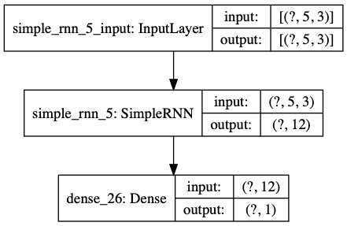

```python
nyse_rnn_01 = keras.models.Sequential([
    keras.layers.SimpleRNN(units = 12, input_shape = (5, 3),
    dropout = 0.1, recurrent_dropout = 0.1),
    keras.layers.Dense(units = 1)
])

print(nyse_rnn_01.summary());

plot_model(nyse_rnn_01, show_shapes = True, show_layer_names = True)
```

```python
nyse_rnn_01.compile(optimizer = 'RMSprop', loss = 'mse')
```

```python
# Output has been removed for brevity
nyse_rnn_01_history = nyse_rnn_01.fit(
    x = features_train_rnn, y = target_train, batch_size = 64,
    epochs = 200,
    validation_data = (features_test_rnn, target_test)
)
```

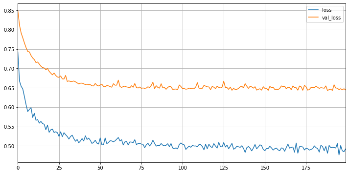

```python
pd.DataFrame(nyse_rnn_01_history.history).plot(figsize = (12, 6), grid = True)
```

Training and validation loss both seem to plateau at about 50 epochs. Validation loss is substantially higher than training loss, suggesting there is a lot of overfitting.

```python
nyse_rnn_01_pred = nyse_rnn_01.predict(features_test_rnn)
nyse_rnn_01_r2_score = r2_score(y_true = target_test, y_pred = nyse_rnn_01_pred)
print(f"RNN 01 w/o DoW gives R-squared: {np.round(nyse_rnn_01_r2_score, 3)}")
```

```
RNN 01 w/o DoW gives R-squared: 0.403
```

This is quite a bit lower than the value of 0.416 reported in the book. However, directionally, it is aligned: the RNN does much worse than an autoregression model with the `day_of_week` variable, and slightly worse than the the autoregression model witout `day_of_week`.

## Feed Forward Neural Network - With `day_of_week`

To replicate the logic of a non-linear autoregression model, we don't use a recurrent neural network. Instead, we just use a feedforward neural network with the day-wise lagged features and one-hot encoded `day_of_week` features as predictors.

```python
pd.Series(nyse_train_dow.columns)
```

```
0          DJ_return_L1
1         log_volume_L1
2     log_volatility_L1
3          DJ_return_L2
4         log_volume_L2
5     log_volatility_L2
6          DJ_return_L3
7         log_volume_L3
8     log_volatility_L3
9          DJ_return_L4
10        log_volume_L4
11    log_volatility_L4
12         DJ_return_L5
13        log_volume_L5
14    log_volatility_L5
15                  fri
16                  mon
17                 thur
18                 tues
19                  wed
dtype: object
```

```python
print("features_train: ", nyse_train_dow.shape)
print("features_test: ", nyse_test_dow.shape)
print("target_train: ", target_train.shape)
print("target_test: ", target_test.shape)
```

```
features_train:  (4276, 20)
features_test:  (1765, 20)
target_train:  (4276,)
target_test:  (1765,)
```

```
Model: "sequential_21"
_________________________________________________________________
Layer (type)                 Output Shape              Param #
=================================================================
dense_31 (Dense)             (None, 32)                672
_________________________________________________________________
dropout_11 (Dropout)         (None, 32)                0
_________________________________________________________________
dense_32 (Dense)             (None, 1)                 33
=================================================================
Total params: 705
Trainable params: 705
Non-trainable params: 0
_________________________________________________________________
None
```

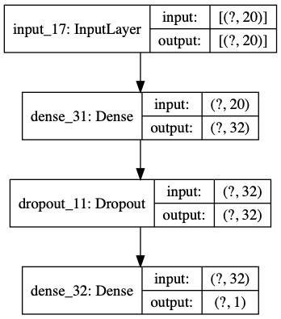

```python
nyse_ann_model = keras.models.Sequential([
    keras.layers.Input(shape = (nyse_train_dow.shape[1],)),
    keras.layers.Dense(units = 32, activation = 'relu'),
    keras.layers.Dropout(rate = 0.5),
    keras.layers.Dense(units = 1)
])

print(nyse_ann_model.summary())

plot_model(nyse_ann_model, show_shapes = True, show_layer_names = True)
```

```python
nyse_ann_model.compile(optimizer = 'RMSprop', loss = 'mse')

nyse_ann_model_history = nyse_ann_model.fit(
    x = nyse_train_dow, y = target_train, epochs = 100, batch_size = 32,
    validation_data = (nyse_test_dow, target_test)
)
```

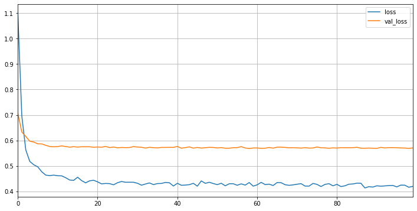

```python
pd.DataFrame(nyse_ann_model_history.history).plot(
    figsize = (12, 6), grid = True
)
```

The validation loss is now substantially lower compared to the previous model. However, the difference in training and validation loss is still quite high, suggesting overfitting.

```python
nyse_ann_model_pred = nyse_ann_model.predict(nyse_test_dow)
nyse_ann_model_r2_score = r2_score(y_true = target_test, y_pred = nyse_ann_model_pred)
print(f"Non-linear Autoregression with ANN has R2 score: {np.round(nyse_ann_model_r2_score, 3)}")
```

```
Non-linear Autoregression with ANN has R2 score: 0.471
```

Summarising all models on the timeseries data.

```python
pd.DataFrame({
    'model_names': ['linear_autoreg', 'linear_autoreg_weekday',
                   'rnn', 'non_linear_ann_autoreg_weekday'],
    'r2_score': [
        nyse_ar_r2_score, nyse_ar_dow_r2_score, nyse_rnn_01_r2_score,
        nyse_ann_model_r2_score
    ]
})
```

|  | model_names | r2_score |
| --- | --- | --- |
| 0 | linear_autoreg | 0.413561 |
| 1 | linear_autoreg_weekday | 0.459761 |
| 2 | rnn | 0.402877 |
| 3 | non_linear_ann_autoreg_weekday | 0.471299 |

The non-linear autoregressor implemented with the `day_of_week` feature has the highest test-set $R^2$ score.